# JHDS_RR_PA1

```r
  row_with_NA <- data[!row_has_na,]
```

```r
  print(nrow(row_with_NA))
```

```
## [1] 15264
```

2. STRATEGY Convert NA Step values to their respective interval mean (integers)
3. CREATE a new data set
- Transform: populate table “idata” that includes “data” table and “respective interval means”

```r
  setnames(steps_interval_mean, "Interval", "interval")

  idata <- merge(x = data, y = steps_interval_mean, by = "interval", all.x=TRUE)

  idata$Steps_mean <- as.integer(idata$Steps_mean+0.5)

  idata <-
    idata %>%
            mutate(steps=ifelse(is.na(steps)|steps == "NA", Steps_mean, steps))

  idata <- idata %>% select(interval, steps, date, date_time, Steps_mean)

  idata$steps <- as.integer(idata$steps)
```

```
- Transform data: Populate new table "isteps_day", aggregates date and sums steps
```

```r
  isteps_day <- aggregate(idata$steps, by = list(idata$date), FUN=sum, na.rm=TRUE)
  isteps_day <- data.table(isteps_day)
  setnames(isteps_day, "Group.1", "Date")
  setnames(isteps_day, "x", "Steps")
```

4. HISTOGRAM of the total number of steps taken each day

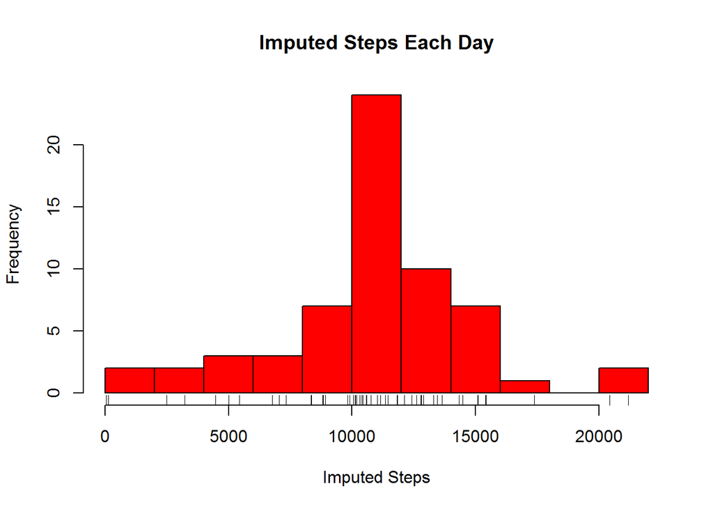

```r
  x <- (isteps_day$Steps)
  hist(x, breaks=12, main="Imputed Steps Each Day",xlab="Imputed Steps", col="red")
  rug(x,side=1)
```

- Calculate and report the mean steps per day of imputed data

```r
  print(mean(isteps_day$Steps))
```

```
## [1] 10765.64
```

- Calculate and report the median steps per day of imputed data

```r
  print(median(isteps_day$Steps))
```

```
## [1] 10762
```

- Do these values differ from the estimates from the non-imputed data?

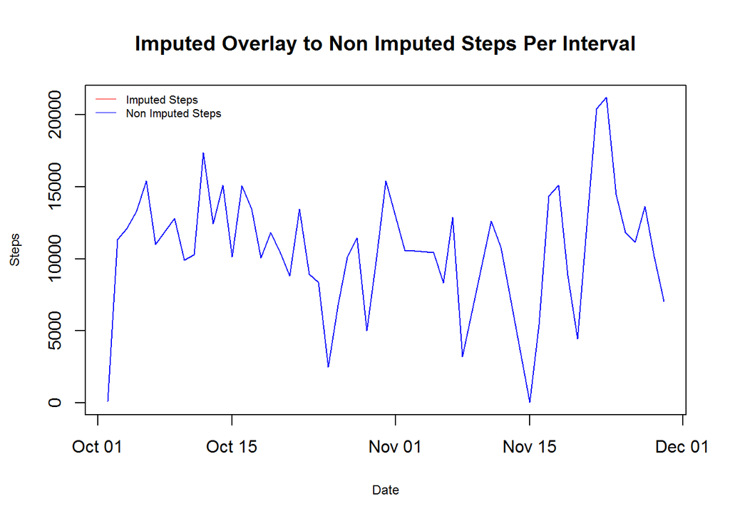

```r
  x <- isteps_day$Date
  y <- isteps_day$Steps
  xi <- steps_day$Date
  yi <- steps_day$Steps
  plot(xi, yi, type="n", xlab="Date", ylab="Steps", cex.lab=".75", main = "Imputed Overlay to Non Imputed Steps Per Interval")
  points(x, y, type="l", col="red")
  points(xi, yi, type="l", col="blue")
  legend("topleft",legend = c("Imputed Steps", "Non Imputed Steps"), col = c("red", "blue"), lwd = .75, cex = .65, bty="n")
```

```r
  isteps_interval_mean <- aggregate(idata$steps, by = list(idata$interval), FUN=mean, na.rm=TRUE)
  isteps_interval_mean <- data.table(isteps_interval_mean)
  setnames(isteps_interval_mean, "Group.1", "Interval")
  setnames(isteps_interval_mean, "x", "Steps_mean")
  i_interval_max_mean <- filter(isteps_interval_mean, isteps_interval_mean$Steps_mean == max(isteps_interval_mean$Steps_mean))
  i_interval_max_mean <- data.table(i_interval_max_mean)
```

- Imputed MAX mean for intervals and days

```r
  print(i_interval_max_mean)
```

```
##    Interval Steps_mean
## 1:      835   206.1475
```

- NON-Imputed MAX mean for intervals and days

```r
  print(interval_max_mean)
```

```
##    Interval Steps_mean
## 1:      835   206.1698
```

- Mean for days did change: comparing interval non-imputed means to imputed means
- Imputed mean for days

```r
  print(mean(isteps_day$Steps))
```

```
## [1] 10765.64
```

- NON-Imputed mean for days

```r
  print(mean(steps_day$Steps))
```

```
## [1] 10766.19
```

**Differences in Activity Patterns Between Weekdays and Weekends**

1. Transform data: add column “wend” to imputed data table “idata”

```r
  idata$wend <- as.factor(ifelse(weekdays( idata$date_time) %in% c("Saturday","Sunday"), "Weekend", "Weekday"))
```

- Transform data: populate table “isteps_interval_mean_wk$Steps_mean”

```r
  isteps_interval_mean_wk <- aggregate(idata$steps, by = list(idata$interval, idata$wend), FUN=mean, na.rm=TRUE)
  setnames(isteps_interval_mean_wk, "Group.1", "Interval")
  setnames(isteps_interval_mean_wk, "x", "Steps_mean")
  setnames(isteps_interval_mean_wk, "Group.2", "Weekday")
  isteps_interval_mean_wk$Steps_mean <- as.integer(isteps_interval_mean_wk$Steps_mean+0.5)
```

2. Panel plot of the 5-minute interval and average number of steps taken, averaged across all weekday days or weekend days

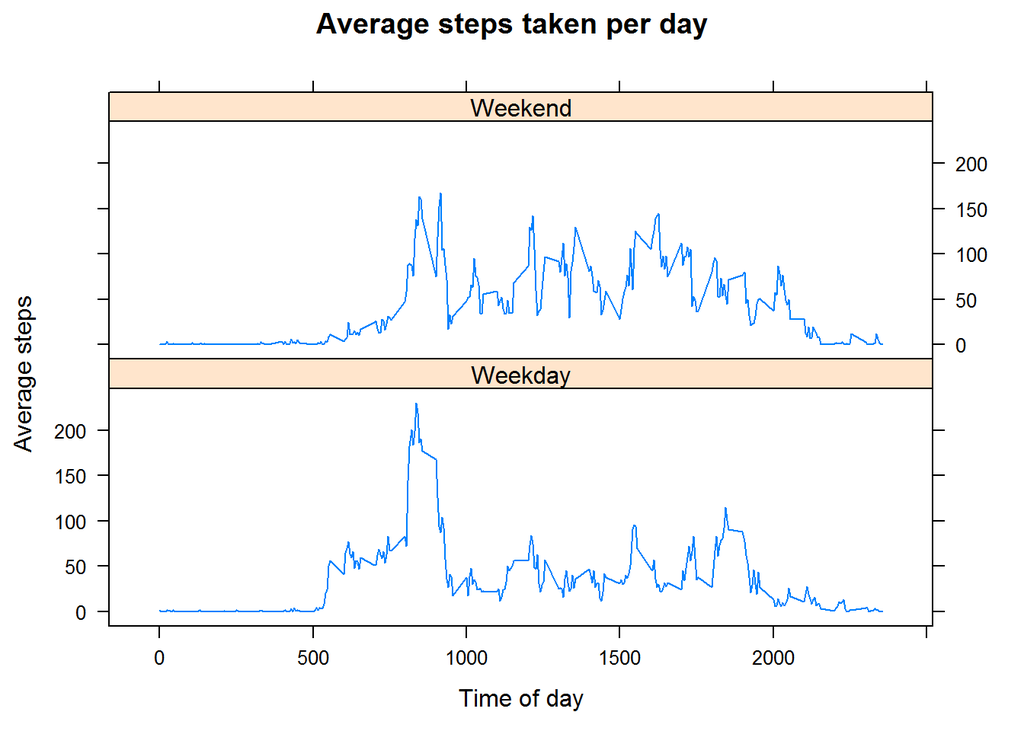

```r
  g <- xyplot(Steps_mean ~ Interval | Weekday, data = isteps_interval_mean_wk, type = "l" , layout = c(1,2), xlab="Time of day", ylab="Average steps",
              scales=list( Steps_mean=list(tick.number=5)),
              main="Average steps taken per day"
           )
  print(g)
```